# El lenguaje de programación R - Datos vectoriales - introducción

Manuel Vargas

2020-09-30

El código fuente de este documento está disponible en https://github.com/pf0953-programaciongeoespacialr-2020/leccion-06-r-datos-vectoriales-introduccion.git.

## Recursos de interés

- Sitio web del curso: [PF0953 Programación geoespacial en R](https://pf0953-programaciongeoespacialr-2020.github.io/)
- Datos utilizados en el curso: [Datos del curso PF0953 Programación geoespacial en R](https://github.com/pf0953-programaciongeoespacialr-2020/datos)
- [Geocomputation with R - Chapter 1 Introduction](https://geocompr.robinlovelace.net/intro.html)
- [Geocomputation with R - Chapter 2 Geographic data in R](https://geocompr.robinlovelace.net/spatial-class.html)
- Sitio web del estándar *Simple Features*: [Simple Features](https://www.ogc.org/standards/sfa)
- Sitio oficial del paquete sf: [sf](https://cran.r-project.org/web/packages/sf/)

## El modelo de datos vectorial

El modelo de datos vectorial está basado en puntos localizados en un [sistema de referencia de coordenadas (CRS)](https://en.wikipedia.org/wiki/Spatial_reference_system). Los puntos individuales pueden representar objetos independientes (ej. la localización de un poste eléctrico o de una cabina telefónica) o pueden también agruparse para formar geometrías más complejas como líneas o polígonos. Por lo general, los puntos tienen solo dos dimensiones (x, y), a las que se les puede agregar una tercera dimensión *z*, usualmente correspondiente a la altitud sobre el nivel del mar.

## El estándar *Simple Features*

[*Simple Features*](https://www.ogc.org/standards/sfa) (o *Simple Feature Access*) es un estándar abierto de la [Organización Internacional de Estandarización (ISO)](https://iso.org/) y del [*Open Geospatial Consortium* (OGC)](https://www.ogc.org/) que especifica un modelo común de almacenamiento y acceso para geometrías de dos dimensiones (líneas, polígonos, multilíneas, multipolígonos, etc.). El estándar es implementado por muchas bibliotecas y bases de datos geoespaciales como [sf](https://cran.r-project.org/web/packages/sf/index.html), [GDAL](https://gdal.org/), [PostgreSQL/PostGIS](https://en.wikipedia.org/wiki/PostGIS), [SQLite/SpatiaLite](https://www.gaia-gis.it/fossil/libspatialite/), [Oracle Spatial](https://www.oracle.com/database/technologies/spatialandgraph.html) y [Microsoft SQL Server](https://www.microsoft.com/en-us/sql-server/), entre muchas otras.

La especificación define 17 tipos de geometrías, de las cuales siete son las más comúnmente utilizadas. Estas últimas se muestran en la figura 1:

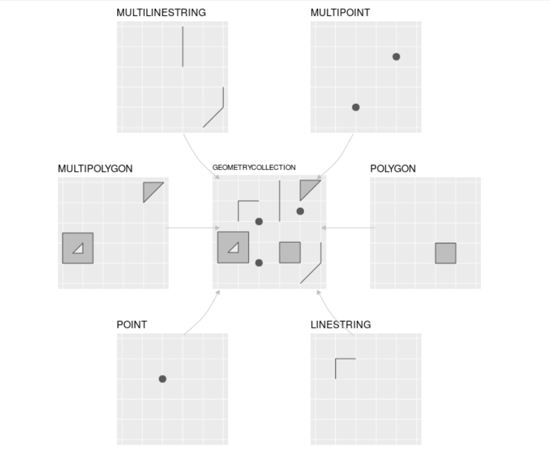

Figura 1: Tipos de geometrías de Simple Features más usadas. Imagen de Robin Lovelace et al. (https://geocompr.robinlovelace.net/spatial-class.html#vector-data)

## El paquete sf

El paquete [sf](https://cran.r-project.org/web/packages/sf/) (de *Simple Features*) de R implementa los modelos de datos de las geometrías de tipo vectorial: puntos, líneas, polígonos, sus versiones múltiples y las colecciones de geometrías. Está basado en bibliotecas de sofware ampliamente utilizadas en aplicaciones geoespaciales:

- **GDAL**: [Geospatial Data Abstraction Library (GDAL)](https://gdal.org/) es una biblioteca para leer y escribir datos geoespaciales en varios formatos [raster](https://gdal.org/drivers/raster/) y [vectoriales](https://gdal.org/drivers/vector/). Implementa un único [modelo abstracto de datos raster](https://gdal.org/user/raster_data_model.html) y un único [modelo abstracto de datos vectoriales](https://gdal.org/user/vector_data_model.html), lo que permite programar aplicaciones geoespaciales sin tener que ocuparse de las particularidades de cada formato que se utilice (GeoTIFF, NetCDF, ESRI Shapefile, GeoJSON, etc.). A pesar de que GDAL está programada en C/C++, cuenta con una interfaz de programación de aplicaciones (API) para varios lenguajes de programación, incluyendo [C](https://gdal.org/api/index.html#c-api), [C++](https://gdal.org/api/index.html#id3), [Python](https://gdal.org/python/index.html) y [Java](https://gdal.org/java/overview-summary.html). Además, ofrece un conjunto de [utilitarios de línea de comandos](https://gdal.org/programs/) cuyas [distribuciones binarias](https://gdal.org/download.html#binaries) están disponibles para varios sistemas operativos, incluyendo Windows, macOS y Linux.
- **GEOS**: [Geometry Engine, Open Source (GEOS)](https://trac.osgeo.org/geos) es una implmentación en C++ de la biblioteca [JTS Topology Suite](http://www.tsusiatsoftware.net/jts/main.html) (desarrollada en Java) y que implementa un conjunto de operaciones y predicados geoespaciales (ej. unión, intersección, distancia, área).
- **PROJ**: [PROJ](https://proj.org/) es una biblioteca que transforma coordenadas entre diferentes CRS, incluyendo tanto proyecciones cartográficas como transformaciones geodésicas.

sf provee acceso, desde un mismo paquete de R, a la funcionalidad de estas tres bibliotecas, proporcionando así una interfaz unificada para leer y escribir datos geoespaciales mediante GDAL, realizar operaciones con geometrías mediante GEOS y efectuar transformaciones entre sistemas de coordenadas mediante PROJ.

sf cuenta con varias ventajas con respecto a otros paquetes geoespaciales de R (ej. sp):

- Rápida lectura y escritura de datos.
- Rendimiento de graficación mejorado.
- Manejo de objetos como data frames.
- Las funciones pueden combinarse con el operador %>%, lo que las combina bien con los paquetes de [tidyverse](https://www.tidyverse.org/).
- Los nombres de las funciones son consistentes e intuitivos (comienzan con `st_`).

En sf, los conjuntos de datos geoespaciales se almacenan en un data frame que contiene una columna especial para las geometrías. Esta columna se denomina generalmente `geom` o `geometry`. El manejo de datos geoespaciales como data frames, permite manipularlos con las funciones ya desarrolladas para data frames (ej. `summary()`, `View()`, `str()`) y con la misma forma de referencias las filas (observaciones) y las columnas (variables).

### Instalación y carga de sf

Instalación:

```r
# Instalación de sf
install.packages("sf")
```

Carga:

```r
# Carga de sf
library(sf)
```

Documentación:

```r
 # Páginas disponibles
vignette(package = "sf")

# Página introductoria
vignette("sf1")
```

### Instalación de conjuntos de datos utilizados en los ejemplos

Para ejemplos, se utilizarán los conjuntos de datos [spData](https://cran.r-project.org/web/packages/spData/) y spDataLarge.

```r
# Instalación de spData
install.packages("spData")

# Instalación de spDataLarge
install.packages("remotes")
remotes::install_github("Nowosad/spDataLarge")
```

Carga:

```r
# Carga de spData y spDataLarge
library(spData)
library(spDataLarge)
```

### Ejemplos de uso de sf

En los siguientes ejemplos, se utilizará el conjunto de datos world de `spData`.

#### Exploración inicial de datos

Con la función [names()](https://www.rdocumentation.org/packages/base/versions/3.6.2/topics/names), pueden desplegarse los nombres de las columnas de un data frame:

```r
# Despliegue de los nombres de columnas
names(world)
```

```
##  [1] "iso_a2"    "name_long" "continent" "region_un" "subregion" "type"
##  [7] "area_km2"  "pop"       "lifeExp"   "gdpPercap" "geom"
```

```r
# Estructura del data frame
str(world)
```

```
## tibble [177 x 11] (S3: sf/tbl_df/tbl/data.frame)
##  $ iso_a2   : chr [1:177] "FJ" "TZ" "EH" "CA" ...
##  $ name_long: chr [1:177] "Fiji" "Tanzania" "Western Sahara" "Canada" ...
##  $ continent: chr [1:177] "Oceania" "Africa" "Africa" "North America" ...
##  $ region_un: chr [1:177] "Oceania" "Africa" "Africa" "Americas" ...
##  $ subregion: chr [1:177] "Melanesia" "Eastern Africa" "Northern Africa" "Northern America" ...
##  $ type     : chr [1:177] "Sovereign country" "Sovereign country" "Indeterminate" "Sovereign country" ...
##  $ area_km2 : num [1:177] 19290 932746 96271 10036043 9510744 ...
##  $ pop      : num [1:177] 8.86e+05 5.22e+07 NA 3.55e+07 3.19e+08 ...
##  $ lifeExp  : num [1:177] 70 64.2 NA 82 78.8 ...
##  $ gdpPercap: num [1:177] 8222 2402 NA 43079 51922 ...
##  $ geom     :sfc_MULTIPOLYGON of length 177; first list element: List of 3
##   ..$ :List of 1
##   .. ..$ : num [1:8, 1:2] 180 180 179 179 179 ...
##   ..$ :List of 1
##   .. ..$ : num [1:9, 1:2] 178 178 179 179 178 ...
##   ..$ :List of 1
##   .. ..$ : num [1:5, 1:2] -180 -180 -180 -180 -180 ...
##   ..- attr(*, "class")= chr [1:3] "XY" "MULTIPOLYGON" "sfg"
##  - attr(*, "sf_column")= chr "geom"
##  - attr(*, "agr")= Factor w/ 3 levels "constant","aggregate",..: NA NA NA NA NA NA NA NA NA NA
##   ..- attr(*, "names")= chr [1:10] "iso_a2" "name_long" "continent" "region_un" ...
```

Nótese que la columna `geom` contiene las geometrías correspondientes a los multiplígonos de los países.

sf implementa la función llamada `plot()` para visualización de datos geográficos:

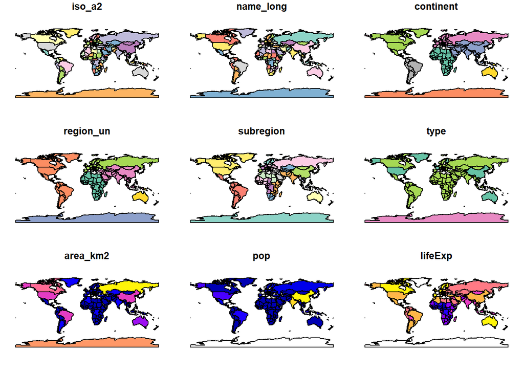

```r
# Despliegue de datos geoespaciales
plot(world)
```

En el ejemplo anterior, se desplegó un mapa por cada variable (i.e. cada columna). `plot()` permite también desplegar el mapa correspondiente a una variable particular:

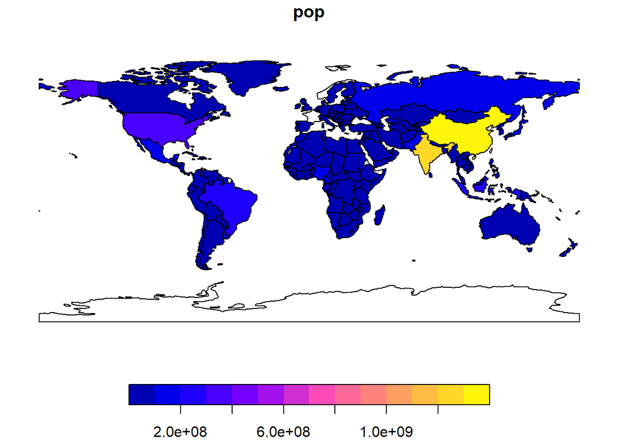

```r
# Despliegue de datos geoespaciales de una columna
plot(world["pop"])
```

#### Filtrado de datos

Puede separarse una “porción” de un data frame geoespacial de la misma forma en la que se hace con cualquier otro data frame:

```r
# Subconjunto de un data frame
world_muestra <- world[1:2, 1:8]

# Despliegue tabular
world_muestra
```

```
## Simple feature collection with 2 features and 8 fields
## geometry type:  MULTIPOLYGON
## dimension:      XY
## bbox:           xmin: -180 ymin: -18.28799 xmax: 180 ymax: -0.95
## geographic CRS: WGS 84
## # A tibble: 2 x 9
##   iso_a2 name_long continent region_un subregion type  area_km2    pop
##   <chr>  <chr>     <chr>     <chr>     <chr>     <chr>    <dbl>  <dbl>
## 1 FJ     Fiji      Oceania   Oceania   Melanesia Sove~   19290. 8.86e5
## 2 TZ     Tanzania  Africa    Africa    Eastern ~ Sove~  932746. 5.22e7
## # ... with 1 more variable: geom <MULTIPOLYGON [°]>
```

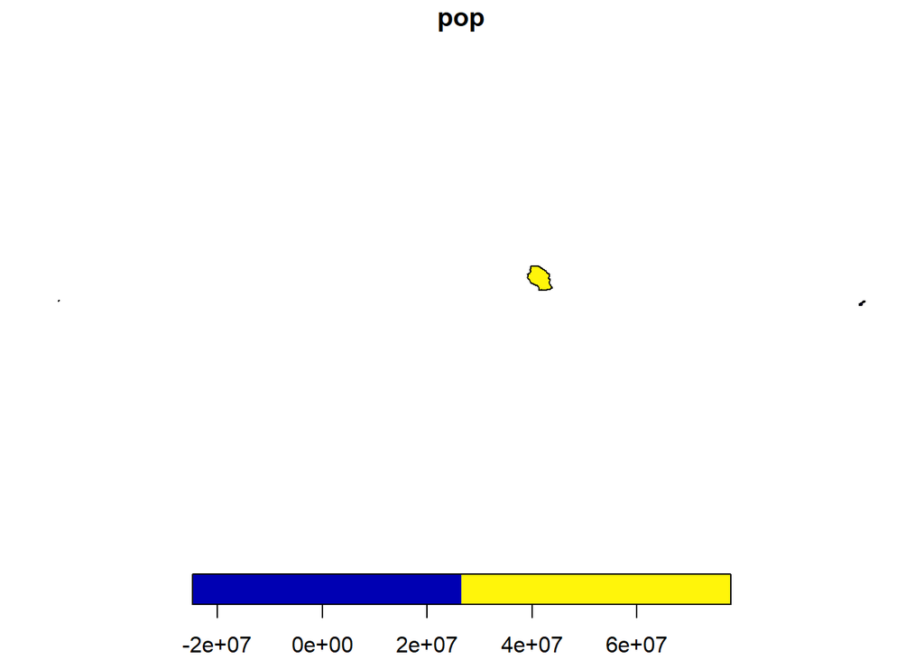

```r
# Despliegue del mapa de población
plot(world_muestra["pop"])
```

También puede realizarse con filtro con base en el valor de los datos de una columna:

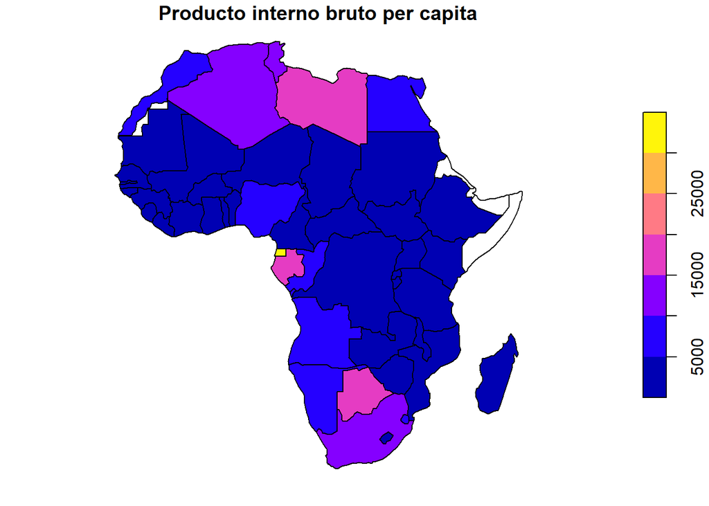

```r
# Países del continente africano
africa_paises = world[world$continent == "Africa", ]

# Mapa de producto interno bruto
plot(
  africa_paises["gdpPercap"],
  main="Producto interno bruto per capita"
)
```

#### Confección de mapas

Es posible agregar capas a un mapa mediante el uso de los parámetros `reset=FALSE` y `add=TRUE` de la función `plot()`.

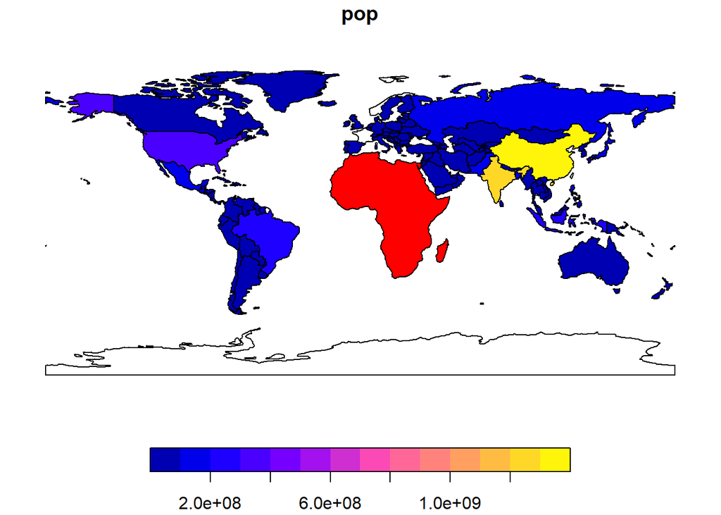

```r
# Filtro para crear data frame con países de África
africa_paises <- world[world$continent == "Africa", ]

# La función st_union() realiza una unión de los polígonos
africa_continente <- st_union(africa_paises)

# Primera capa del mapa
plot(world["pop"], reset=FALSE)
# Segunda capa
plot(africa_continente, add=TRUE, col = "red")
```

#### Lectura y escritura de datos

Las operaciones de lectura tranforman datos contenidos en diferentes fuentes al formato requerido por el paquete sf. La lectura se lleva a cabo con la función `st_read()`. A continuación, se presentan ejemplos para tres tipos diferentes de fuentes de datos:

- Archivos geoespaciales (ej. Shapefile, Geopackage, GeoJSON).
- Servicios WFS.
- Archivos CSV.

Lectura de un archivo geoespacial:

```r
# COVID-19 en cantones de Costa Rica
cr_cantones_covid19 <-
  st_read("https://raw.githubusercontent.com/pf0953-programaciongeoespacialr-2020/datos/master/covid19/casos/cr/cr-covid19-cantones.geojson")
```

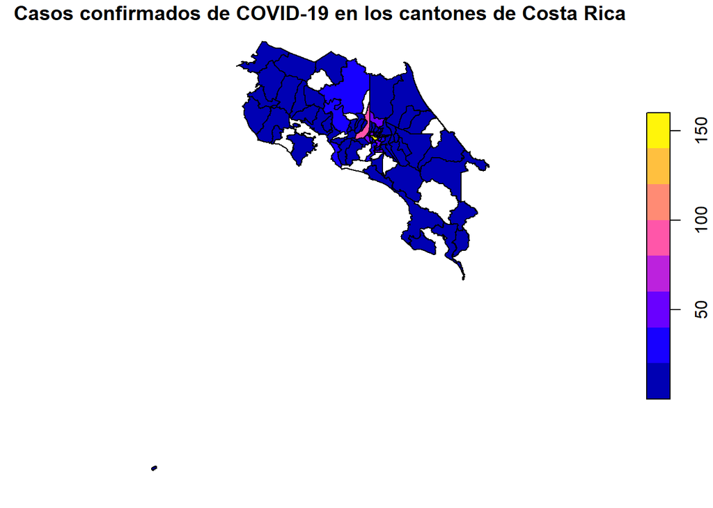

```r
# Mapa de coropletas de casos confirmados de COVID-19
plot(
  cr_cantones_covid19["confirmados"],
  main="Casos confirmados de COVID-19 en los cantones de Costa Rica"
)
```

Lectura de un [Web Feature Service (WFS)](https://www.ogc.org/standards/wfs). Se utiliza una capa publicada por el Instituto Geográfico Nacional (IGN) en la [Infraestructura Nacional de Datos Espaciales de Costa Rica (SNIT)](http://www.snitcr.go.cr/):

```r
# Dirección base del servicio WFS
url_base <- "http://geos.snitcr.go.cr/be/IGN_5/wfs?"

# Parámetros de la solicitud WFS de la capa:
#   typeName: nombre de la capa
#   outputFormat: formato de salida
solicitud_wfs <-
  "request=GetFeature&service=WFS&version=2.0.0&typeName=IGN_5:limiteprovincial_5k&outputFormat=application/json"

# URL completo del servicio WFS
cr_provincias_wfs <- paste0(url_base, solicitud_wfs)

# Recuperación de los datos en un data frame
cr_provincias <- st_read(cr_provincias_wfs)
```

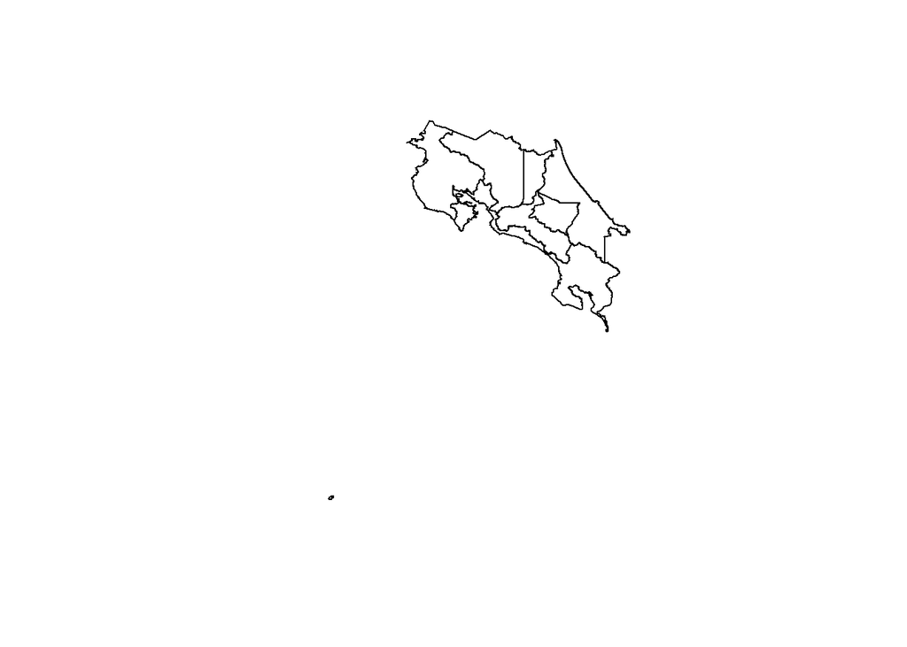

```r
# Mapeo del data frame
plot(cr_provincias$geometry)
```

Lectura de un archivo de valores separados por comas (CSV). Se utilizan datos de presencia de especies agrupados por la [Infraestructura Mundial de Información en Biodiversidad (GBIF)](https://www.gbif.org/):

```r
# Lectura del archivo CSV
cr_ara_ambiguus <-
  st_read(
    "https://raw.githubusercontent.com/pf0953-programaciongeoespacialr-2020/datos/master/biodiversidad/registros-presencia/cr/cr-ara-ambiguus.csv",
    options = c("X_POSSIBLE_NAMES=decimalLongitude","Y_POSSIBLE_NAMES=decimalLatitude")
  )
```

```
## options:        X_POSSIBLE_NAMES=decimalLongitude Y_POSSIBLE_NAMES=decimalLatitude
```

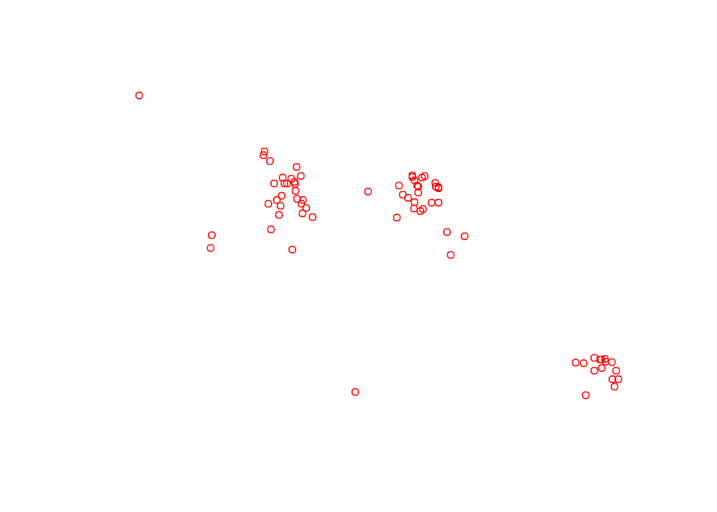

```r
# Mapeo del data frame
plot(
  cr_ara_ambiguus$geometry,
  col="red"
)
```

Mapa de provincias y registros de presencia:

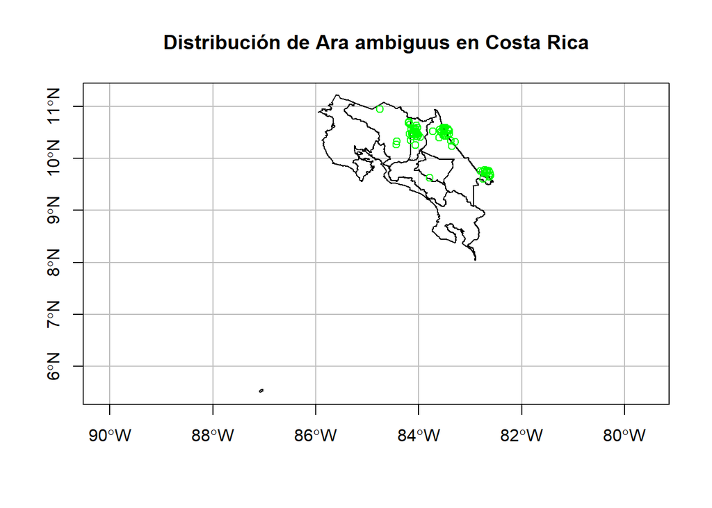

```r
# Se cambia la proyección a WGS84 (EPSG 4326)
cr_provincias_wgs84 = st_transform(cr_provincias, 4326)

# Primera capa del mapa
plot(cr_provincias_wgs84$geometry,
  main="Distribución de Ara ambiguus en Costa Rica",
  reset=FALSE,
  axes = TRUE,
  graticule=TRUE
)

# Segunda capa
plot(
  cr_ara_ambiguus$geometry,
  add = TRUE,
  col = "green"
)
```